# Flights Data Explanation

## by Ainur Artay

## Investigation Overview

This investigation will be focused on the arrival delays of the flights of US in 2008, specifically, the Arrival delays will be analyzed from two angles -- Departure Delay and Elapsed Time Delay. These two parts will be further analyzed by their associated factors -- CarrierDelay, WeatherDelay, NASDelay and LateAircraftDelay.

## Distribution of ArrDelay

ArrDelay in the dataset takes on a very large range of values, most of them are from about -50 to about 150 minutes, with the mean arount 0. Negative value means the plane arrived earlier than scheduled.

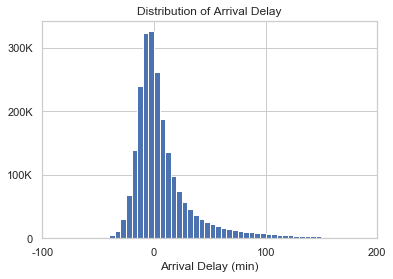

```python
bin = np.arange(-50, 200, 5)
plt.hist(data=df, x="ArrDelay", bins=bin)
plt.title("Distribution of Arrival Delay")
plt.xlabel("Arrival Delay (min)")
plt.xlim(-50,200)
plt.xticks(np.arange(-100,300,100),np.arange(-100,300,100))
plt.yticks(np.arange(0,400000,100000),[0,"100K","200K","300K","400K"]);
```

## Distributions of DepDelay and delay_elapsed

DepDelay is more right-skewed and the spread is higher, while the delay_elapsed is more symmetric and with lower spread.

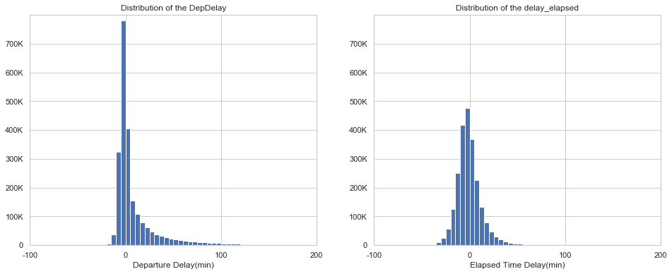

```python
# plot the histgram again in the limit of [-50<x<200]
bin = np.arange(-50, 200, 5)
plt.figure(figsize=[16,6])
plt.subplot(1,2,1)
plt.hist(data=df, x="DepDelay",bins=bin)
plt.title("Distribution of the DepDelay")
plt.xlabel("Departure Delay(min)")
plt.xlim(-100,200)
plt.ylim(0,800000)
plt.xticks(np.arange(-100,300,100),np.arange(-100,300,100))
plt.yticks(np.arange(0,800000,100000),[0,"100K","200K","300K","400K","500K","600K","700K","800K"]);

plt.subplot(1,2,2)
plt.hist(data=df, x="delay_elapsed",bins=bin)
plt.title("Distribution of the delay_elapsed")
plt.xlabel("Elapsed Time Delay(min)")
plt.xlim(-100,200)
plt.ylim(0,800000)
plt.xticks(np.arange(-100,300,100),np.arange(-100,300,100))
plt.yticks(np.arange(0,800000,100000),[0,"100K","200K","300K","400K","500K","600K","700K","800K"]);
```

## What isthe relationship among DepDelay and delay_elapsed and ArrDelay?

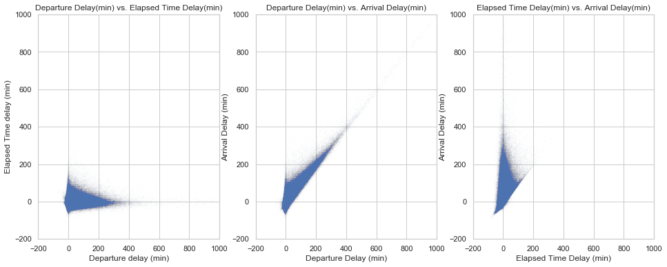

```python
plt.figure(figsize=[16,6])

plt.subplot(1,3,1)
plt.title("Departure Delay(min) vs. Elapsed Time Delay(min)")
plt.scatter(data=df, x="DepDelay", y="delay_elapsed", s=0.5, alpha=0.01)
plt.xlabel("Departure delay (min)")
plt.ylabel("Elapsed Time delay (min)");
plt.xlim([-200,1000])
plt.ylim([-200,1000]);

plt.subplot(1,3,2)
plt.title("Departure Delay(min) vs. Arrival Delay(min)")
plt.scatter(data=df, x="DepDelay", y="ArrDelay", s=0.5, alpha=0.01)
plt.xlabel("Departure Delay (min)")
plt.ylabel("Arrival Delay (min)")
plt.xlim([-200,1000])
plt.ylim([-200,1000]);

plt.subplot(1,3,3)
plt.title("Elapsed Time Delay(min) vs. Arrival Delay(min)")
plt.scatter(data=df, x="delay_elapsed", y="ArrDelay", s=0.5, alpha=0.01)
plt.xlabel("Elapsed Time Delay (min)")
plt.ylabel("Arrival Delay (min)")
plt.xlim([-200,1000])
plt.ylim([-200,1000]);
```

## Attributes of the delay factors

> 1.Occurence Rates NSADelay was the most prevalent delay factor in 2008, affecting more than 14% of the flights. The LateAircraftDelay and CarrierDelay followed with aound 12% and 11%, respectively. The WeatherDelay was registered less than 2% of the time.

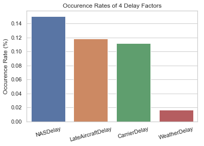

```python
# The proportion where each type of delay occurs.
p_car = df[(~df.CarrierDelay.isnull()) & (df.CarrierDelay!=0)].shape[0] / df.shape[0]
p_wea = df[(~df.WeatherDelay.isnull()) & (df.WeatherDelay!=0)].shape[0] / df.shape[0]
p_nas = df[(~df.NASDelay.isnull()) & (df.NASDelay!=0)].shape[0] / df.shape[0]
p_sec = df[(~df.SecurityDelay.isnull()) & (df.SecurityDelay!=0)].shape[0] / df.shape[0]
p_airc = df[(~df.LateAircraftDelay.isnull()) & (df.LateAircraftDelay!=0)].shape[0] / df.shape[0]

delays = pd.Series([p_nas,p_airc,p_car,p_wea], index=["NASDelay","LateAircraftDelay","CarrierDelay","WeatherDelay"]).sort_values(ascending=False)
sb.barplot(delays.index, delays)
plt.xticks(rotation=15)
plt.title("Occurence Rates of 4 Delay Factors")
plt.ylabel("Occurence Rate (%)");
```

> 1. Distribution of delay times This shows the distribution of the length of a delay each factor generates. 2 graphs are actually the same and one on the right is just an enlarged version. The distributions of delay times of the factors are not significantly different.

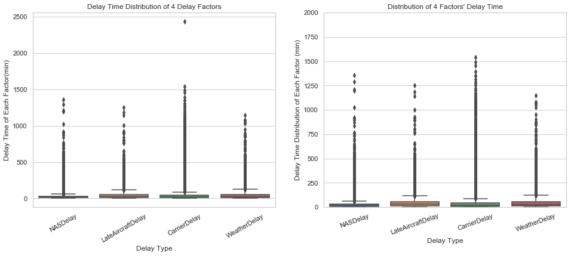

```python
# take a look at the distribution on how many minutes each delay factor can prolong the flight time
plt.figure(figsize=[16,6])

plt.subplot(1,2,1)
plt.title("Delay Time Distribution of 4 Delay Factors")
sb.boxplot(data= dummy, x="Delay Factor", y="time")
plt.xlabel("Delay Type")
plt.ylabel("Delay Time of Each Factor(min)")
plt.xticks(rotation=30);

plt.subplot(1,2,2)
plt.title("Distribution of 4 Factors' Delay Time")
sb.boxplot(data= dummy, x="Delay Factor", y="time")
plt.xlabel("Delay Type")
plt.ylabel("Delay Time Distribution of Each Factor (min)")
plt.ylim([0,2000])
plt.xticks(rotation=20);
```

## What is the relationship of the Distance and ArrDelay/DepDelay/delay_elapsed?

The plots below suggest an interesting observation, which is long distances are not linked with long delays, most of the delays happen on short distance flights.

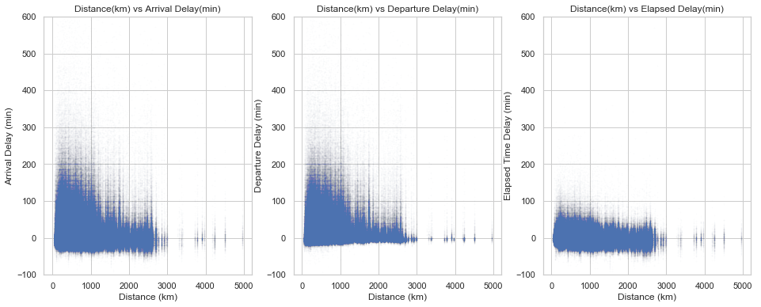

```python
plt.figure(figsize=[16,6])

plt.subplot(1,3,1)
plt.title("Distance(km) vs Arrival Delay(min)")
plt.scatter(data=df, x="Distance", y="ArrDelay", s=0.5, alpha=0.01)
plt.xlabel("Distance (km)")
plt.ylabel("Arrival Delay (min)")
plt.ylim([-100,600]);

plt.subplot(1,3,2)
plt.title("Distance(km) vs Departure Delay(min)")
plt.scatter(data=df, x="Distance", y="DepDelay", s=0.5, alpha=0.01)
plt.xlabel("Distance (km)")
plt.ylabel("Departure Delay (min)")
plt.ylim([-100,600]);

plt.subplot(1,3,3)
plt.title("Distance(km) vs Elapsed Delay(min)")
plt.scatter(data=df, x="Distance", y="delay_elapsed", s=0.5, alpha=0.01)
plt.xlabel("Distance (km)")
plt.ylabel("Elapsed Time Delay (min)")
plt.ylim([-100,600]);
```

## What is the relationship between the Distance & four factors of delay?

This part supports the observation from the previous part, which is there's no clear relationship between the distance and pther factors.

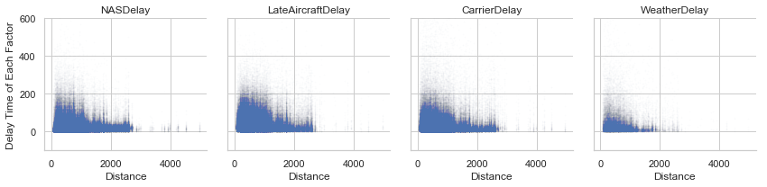

```python
g = sb.FacetGrid(data=dummy, col="Delay Factor")
g.map(plt.scatter, "Distance", "time", s=0.5, alpha=0.01)
g.set_ylabels("Delay Time of Each Factor")
g.set_titles("{col_name}")
plt.ylim([-100,600]);
```

## How are each of the delay factors distributed according to the Length of DepDelay?

The delay factors were visualized according their distributtion by clustering the DepDelay length into 4 levels.  
It was observed that the longer the DepDelay time is, the more it is associated with with longer CarrierDelay and WeatherDelay.

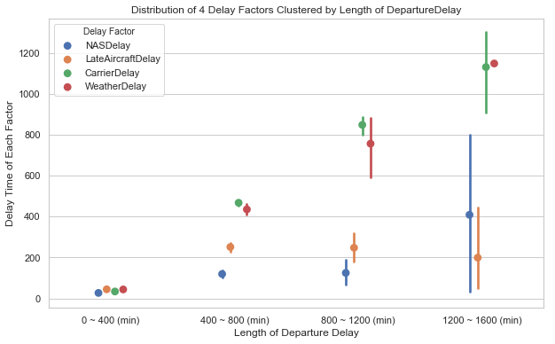

```python
plt.figure(figsize=[10,6])
sb.pointplot(data=dummy, hue="Delay Factor", y="time", x="depdelay_blocked", linestyles="", dodge=0.2)
plt.title("Distribution of 4 Delay Factors Clustered by Length of DepartureDelay")
plt.xlabel("Length of Departure Delay")
plt.ylabel("Delay Time of Each Factor")
plt.xticks([0,1,2,3],["0 ~ 400 (min)","400 ~ 800 (min)", "800 ~ 1200 (min)","1200 ~ 1600 (min)"]);
```

## How is each of the delay factors distributed according to the length of delay_elapsed?

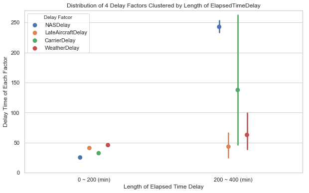

```python
plt.figure(figsize=[10,6])
sb.pointplot(data=dummy, hue="Delay Factor", y="time", x="elapsed_blocked", linestyles="", dodge=0.2)
plt.title("Distribution of 4 Delay Factors Clustered by Length of ElapsedTimeDelay")
plt.xlabel("Length of Elapsed Time Delay")
plt.ylabel("Delay Time of Each Factor")
plt.legend(title="Delay Fatcor", loc='upper left')
plt.xticks([0,1],["0 ~ 200 (min)","200 ~ 400 (min)"])
plt.ylim([0,270]);
```